# heatflux.Rmd

Leeya Pressburger

2/18/2022

## Processing ocean heat flux data from CMIP6

First, I read in the CMIP6 csv files that I accessed with Pangeo in Python and created an output data frame for all six heat flux variables.

```r
library(readr)
library(dplyr)
library(tidyr)
library(ggplot2)
library(here)

BASE_DIR <- here::here()

# Variables of interest
vars <- c("hfls", "hfss", "rlds", "rlus", "rsds", "rsus")

# Function to get lists of file paths for each of the six variables
get_path <- function(var){
  assign(x = paste0("path_", var),
         value = file.path(BASE_DIR, "heat_flux", var))
}

# Access file paths for specified variables
paths <- lapply(vars, get_path)
paths <- c(paths[[1]], paths[[2]], paths[[3]], paths[[4]], paths[[5]], paths[[6]])

# Function to list the files for each path specified
list_files <- function(path){
  list.files(path = path, pattern = "*.csv", full.names = TRUE)
}

# List files for specified paths
files <- lapply(paths, list_files)

# For each file in each file path for each variable, read in the csv data
# Force column types
output <- list()
for(num in 1:length(files)){
  output[[num]] <- lapply(files[[num]], read_csv, col_types = "dccccccdd") %>%
    bind_rows(.id = "File")
}

# Create data frame
output <- bind_rows(output)

head(output)
```

```
## # A tibble: 6 x 11
##   File     X1 variable experiment units frequency ensemble model      year value
##   <chr> <dbl> <chr>    <chr>      <chr> <chr>     <chr>    <chr>     <dbl> <dbl>
## 1 1         0 hfls     1pctCO2    W m-2 mon       r1i1p1f1 ACCESS-C~   950  121.
## 2 1         1 hfls     1pctCO2    W m-2 mon       r1i1p1f1 ACCESS-C~   951  121.
## 3 1         2 hfls     1pctCO2    W m-2 mon       r1i1p1f1 ACCESS-C~   952  120.
## 4 1         3 hfls     1pctCO2    W m-2 mon       r1i1p1f1 ACCESS-C~   953  121.
## 5 1         4 hfls     1pctCO2    W m-2 mon       r1i1p1f1 ACCESS-C~   954  121.
## 6 1         5 hfls     1pctCO2    W m-2 mon       r1i1p1f1 ACCESS-C~   955  121.
## # ... with 1 more variable: x <chr>
```

Next, I added name and row number columns to more easily manipulate the data later. I also corrected the years of the CO<sub>2</sub> forcing experiments to have a start year of 1850.

```r
# Add name and row number identifiers to output dataframe
output$name <- paste0(output$model, "_",
                      output$ensemble, "_",
                      output$experiment)

output$rownum <- seq_len(nrow(output))

# Correct non-conventional years in CO2 forcing experiments
# Scale to start at 1850
output1 <- output %>%
  select("rownum", "year", "File") %>%
  filter(year < 1850 | year > 2500) %>%
  group_by(File) %>%
  mutate(start_year = year[1],
         scale = year - start_year,
         new_year = 1850 + scale) %>%
  select("rownum", "new_year")

# Combine with original dataframe
new_output <- left_join(output, output1, by = "rownum")

head(new_output)
```

```
## # A tibble: 6 x 15
##   File.x    X1 variable experiment units frequency ensemble model     year value
##   <chr>  <dbl> <chr>    <chr>      <chr> <chr>     <chr>    <chr>    <dbl> <dbl>
## 1 1          0 hfls     1pctCO2    W m-2 mon       r1i1p1f1 ACCESS-~   950  121.
## 2 1          1 hfls     1pctCO2    W m-2 mon       r1i1p1f1 ACCESS-~   951  121.
## 3 1          2 hfls     1pctCO2    W m-2 mon       r1i1p1f1 ACCESS-~   952  120.
## 4 1          3 hfls     1pctCO2    W m-2 mon       r1i1p1f1 ACCESS-~   953  121.
## 5 1          4 hfls     1pctCO2    W m-2 mon       r1i1p1f1 ACCESS-~   954  121.
## 6 1          5 hfls     1pctCO2    W m-2 mon       r1i1p1f1 ACCESS-~   955  121.
## # ... with 5 more variables: x <chr>, name <chr>, rownum <int>, File.y <chr>,
## #   new_year <dbl>
```

This next part was a bit tricky. Because of Pangeo complications, there weren’t the same number of files for each variable (ranging from 919 files to 926 files). This chunk tries to isolate only the file names that all six variables share (pardon the hardcoding, I didn’t feel like messing with a function/loop).

```r
# Need to get common names across six variables
names <- unique(new_output$name)

# How many model/experiment/ensemble combinations are there for each variable?
group_by_var <- new_output %>%
  group_by(variable) %>%
  summarize(names = unique(name)) %>%
  mutate(count = length(names))

counts <- group_by_var %>% summarize(variable, count) %>% unique()

# Which variables have the most and least names?
most_names <- group_by_var %>% filter(variable == "rsds")
hfls_names <- group_by_var %>% filter(variable == "hfls")
hfss_names <- group_by_var %>% filter(variable == "hfss")
rlds_names <- group_by_var %>% filter(variable == "rlds")
rlus_names <- group_by_var %>% filter(variable == "rlus")
rsus_names <- group_by_var %>% filter(variable == "rsus")

# Extract common names and names that are missing
common_names <- left_join(most_names, hfls_names, by = "names")
common_names <- left_join(common_names, hfss_names, by = "names")
common_names <- left_join(common_names, rlds_names, by = "names")
common_names <- left_join(common_names, rlus_names, by = "names")
common_names <- left_join(common_names, rsus_names, by = "names")
common_names <- drop_na(common_names)

good_names <- common_names$names

# Manually remove a name that is problematic later
good_names <- good_names[-337]
```

This chunk gets ready to manipulate the data to do the heat flux calculation. It reorganizes the output data frame and selects only the necessary columns.

```r
# Reorganize data frame
data <- new_output %>%
  # Remove pesky NA variable
  filter(variable != "NA") %>%
  # Remove missing names
  filter(name %in% good_names) %>%
  # Organize
  select(-c("X1", "x", "File.x", "File.y")) %>%
  relocate(c("rownum", "name"), .before = "variable")

# Problem - need to make one year column with "year" and "new_year"
# If new_year has an NA, replace it with year, otherwise leave as is
replace_year <- ifelse(is.na(data$new_year),
                data$year,
                data$new_year)
data$year <- replace_year
# Get rid of new_year column
data <- data %>% select(-new_year)

head(data)
```

```
## # A tibble: 6 x 10
##   rownum name     variable experiment units frequency ensemble model  year value
##    <int> <chr>    <chr>    <chr>      <chr> <chr>     <chr>    <chr> <dbl> <dbl>
## 1      1 ACCESS-~ hfls     1pctCO2    W m-2 mon       r1i1p1f1 ACCE~  1850  121.
## 2      2 ACCESS-~ hfls     1pctCO2    W m-2 mon       r1i1p1f1 ACCE~  1851  121.
## 3      3 ACCESS-~ hfls     1pctCO2    W m-2 mon       r1i1p1f1 ACCE~  1852  120.
## 4      4 ACCESS-~ hfls     1pctCO2    W m-2 mon       r1i1p1f1 ACCE~  1853  121.
## 5      5 ACCESS-~ hfls     1pctCO2    W m-2 mon       r1i1p1f1 ACCE~  1854  121.
## 6      6 ACCESS-~ hfls     1pctCO2    W m-2 mon       r1i1p1f1 ACCE~  1855  121.
```

Now for the actual calculation.

```r
# Heat flux equation
# rsds - rsus + rlds - rlus - hfss - hfls

# Select important columns
heat_flux <- data %>% select(c(name, model, experiment, year, variable, value))

# Reshape data
heat_flux <- heat_flux %>%
  group_by(name, year) %>%
  pivot_wider(names_from = variable, values_from = value) %>%
  ungroup()

# Compute equation
hf_output <- list()
for(n in seq_len(nrow(heat_flux))){
  hf_output[[n]] <- heat_flux$rsds[[n]] - heat_flux$rsus[[n]] +
    heat_flux$rlds[[n]] - heat_flux$rlus[[n]] -
    heat_flux$hfss[[n]] - heat_flux$hfls[[n]]
}

# Make output numeric, not a list
hf_output <- as.numeric(as.character(hf_output))

# Combine output with data frame
heat_flux <- heat_flux %>%
  mutate(value = hf_output)

head(heat_flux)
```

```
## # A tibble: 6 x 11
##   name      model  experiment  year hfls   hfss   rlds   rlus  rsds  rsus  value
##   <chr>     <chr>  <chr>      <dbl> <list> <list> <list> <lis> <lis> <lis> <dbl>
## 1 ACCESS-C~ ACCES~ 1pctCO2     1850 <dbl ~ <dbl ~ <dbl ~ <dbl~ <dbl~ <dbl~  3.87
## 2 ACCESS-C~ ACCES~ 1pctCO2     1851 <dbl ~ <dbl ~ <dbl ~ <dbl~ <dbl~ <dbl~  3.42
## 3 ACCESS-C~ ACCES~ 1pctCO2     1852 <dbl ~ <dbl ~ <dbl ~ <dbl~ <dbl~ <dbl~  4.32
## 4 ACCESS-C~ ACCES~ 1pctCO2     1853 <dbl ~ <dbl ~ <dbl ~ <dbl~ <dbl~ <dbl~  3.85
## 5 ACCESS-C~ ACCES~ 1pctCO2     1854 <dbl ~ <dbl ~ <dbl ~ <dbl~ <dbl~ <dbl~  3.37
## 6 ACCESS-C~ ACCES~ 1pctCO2     1855 <dbl ~ <dbl ~ <dbl ~ <dbl~ <dbl~ <dbl~  3.61
```

Now, comparing historical data from CMIP5 to CMIP6.

```r
# Read in csv
hectorcal <- read.csv(file.path(BASE_DIR, "./inputs/CMIP5_heat_flux_final.csv"))
hc <- hectorcal %>% filter(experiment == "historical")

hist <- heat_flux %>%
  filter(experiment == "esm-hist")

# CMIP6
summary(hist$value)
```

```
##    Min. 1st Qu.  Median    Mean 3rd Qu.    Max.
##  0.4704  3.3093  3.6664  3.6454  4.0120  5.6986
```

```r
#CMIP5
summary(hc$value)
```

```
##    Min. 1st Qu.  Median    Mean 3rd Qu.    Max.
## -3.0077  0.8043  1.2469  1.1932  1.6640  3.4791
```

Plotting differences in CMIP5/6

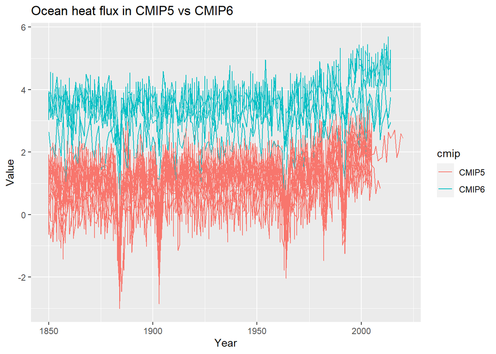

```r
# Select relevant columns, create one dataset
cmip6 <- hist %>%
  select(year, model, value) %>%
  mutate(cmip = "CMIP6")

cmip5 <- hc %>%
  select(year, model, value) %>%
  mutate(cmip = "CMIP5")

mips <- rbind(cmip6, cmip5)

# Plot
ggplot(mips, aes(year, value, color = cmip, group = model)) +
  geom_line() +
  labs(x = "Year",
       y = "Value",
       title = "Ocean heat flux in CMIP5 vs CMIP6")
```